# Employee Attrition Classification

## Abstract

Employee attrition can have ruinous impact on the health of a company. Whenever an experience employee leaves the organization, there is a cost associated with it. A part of this cost is quantifiable numbers and the other part is hidden costs. The quantifiable cost includes the cost incurred in recruiting a replacement and training them. It would be great to have a machine learning model that will help the management to identify the employees who may potentially leave or quit. So that the management can take corrective measures to avoid employee attrition. The intend of the project is to use different classification models and tools available to accurately predict whether an employee will leave the company or not. The various classification techniques used in this project are Logistic Regression classifier, Support vector Machine classifier, Neural Networks and Ensemble methods (Decision Forests). The tools used are python in Jupyter note book and Microsoft Azure Machine Learning

## Introduction

High employee attrition rate is a bad news for any organization. **Employee turnover rate** is number of employees who left during the entire year divided by the total number of employees at the beginning of the year and it is calculated annually. A high employee turnover may be risky for health of the company as high cost are associate with it. The quantifiable cost includes the cost involves recruiting, training etc. Generally, the productivity of the new hire is lower until he/she learn the business. For a customer facing role, if some customer/s are unhappy with the new hire, the business could lose customers who are dissatisfied with service leading to a loss in the revenue. Thus, it is very crucial for company’s management to understand the factors leading to employee attrition and to identify the potential employees who could quit and finally to institutionalized measures to reduce attrition rates.

There can be umpteen reasons for employee attrition. Many of these reasons are personal and may varies from person to person, it can be as diverse as different human personalities. But it is important to analyze some of the basic factors that triggers most resignations?

As discussed, the primary goal of this project is to correctly identify the potential employees in a company who could leave using a classification model.

### Reasons for Employee Attrition

To take corrective measure to stop high attrition rate in an organization, it is important to analyze what are the factors that influences a person’s decision to quite the company. Here are some of the reasons, why an employee might leave his/her current job :-

1. Mostly people leave their employer for an increased paycheck or career advancement,
2. Many researches also shows that often the search for a new position is trigger due to dissatisfaction with an immediate manager.
3. Employee are not engaged and they are bored. High-performing workers need to feel that they are being challenged and are moving forward in terms of professional growth and development.

### About the Data

The dataset was downloaded from Kaggle repository.This is a fictional data set created by *IBM data scientists* to uncover the factors that lead to employee attrition and explore important questions such as ‘show me a breakdown of distance from home by job role and attrition’ or ‘compare average monthly income by education and attrition’. Some of variables used here are:

Education: 1 'Below College' 2 'College' 3 'Bachelor' 4 'Master' 5 'Doctor'  
EnvironmentSatisfaction: 1 'Low' 2 'Medium' 3 'High' 4 'Very High'  
JobInvolvement: 1 'Low' 2 'Medium' 3 'High' 4 'Very High'  
JobSatisfaction: 1 'Low' 2 'Medium' 3 'High' 4 'Very High'  
PerformanceRating:1 'Low' 2 'Good' 3 'Excellent' 4 'Outstanding'  
RelationshipSatisfaction:1 'Low' 2 'Medium' 3 'High' 4 'Very High'  
WorkLifeBalance: 1 'Bad' 2 'Good' 3 'Better' 4 'Best' JobLevel: 1 'Entry' 2 'Intermediate' 3 'Experienced' 4 'Advance' 5 'Expert'

The dataset has 1470 observation and 35 columns.  
The dataset can be downloaded from kaggle [website](https://www.kaggle.com/pavansubhasht/ibm-hr-analytics-attrition-dataset)

### Downloading the Data

After downloading the csv dataset from the above mentioned website into the local system, I use python code below to extract the data for further analysis

```python
# code for downloading the data
import pandas as pd
import numpy as np
Emp_Attrition = pd.read_csv("Employee-Attrition.csv")
print(Emp_Attrition.iloc[:,1:5].head())
Emp_Attrition.describe()
```

```
  Attrition     BusinessTravel  DailyRate              Department
0       Yes      Travel_Rarely       1102                   Sales
1        No  Travel_Frequently        279  Research & Development
2       Yes      Travel_Rarely       1373  Research & Development
3        No  Travel_Frequently       1392  Research & Development
4        No      Travel_Rarely        591  Research & Development
```

|  | Age | DailyRate | DistanceFromHome | Education | EmployeeCount | EmployeeNumber | EnvironmentSatisfaction | HourlyRate | JobInvolvement | JobLevel | ... | RelationshipSatisfaction | StandardHours | StockOptionLevel | TotalWorkingYears | TrainingTimesLastYear | WorkLifeBalance | YearsAtCompany | YearsInCurrentRole | YearsSinceLastPromotion | YearsWithCurrManager |
| --- | --- | --- | --- | --- | --- | --- | --- | --- | --- | --- | --- | --- | --- | --- | --- | --- | --- | --- | --- | --- | --- |
| count | 1470.000000 | 1470.000000 | 1470.000000 | 1470.000000 | 1470.0 | 1470.000000 | 1470.000000 | 1470.000000 | 1470.000000 | 1470.000000 | ... | 1470.000000 | 1470.0 | 1470.000000 | 1470.000000 | 1470.000000 | 1470.000000 | 1470.000000 | 1470.000000 | 1470.000000 | 1470.000000 |
| mean | 36.923810 | 802.485714 | 9.192517 | 2.912925 | 1.0 | 1024.865306 | 2.721769 | 65.891156 | 2.729932 | 2.063946 | ... | 2.712245 | 80.0 | 0.793878 | 11.279592 | 2.799320 | 2.761224 | 7.008163 | 4.229252 | 2.187755 | 4.123129 |
| std | 9.135373 | 403.509100 | 8.106864 | 1.024165 | 0.0 | 602.024335 | 1.093082 | 20.329428 | 0.711561 | 1.106940 | ... | 1.081209 | 0.0 | 0.852077 | 7.780782 | 1.289271 | 0.706476 | 6.126525 | 3.623137 | 3.222430 | 3.568136 |
| min | 18.000000 | 102.000000 | 1.000000 | 1.000000 | 1.0 | 1.000000 | 1.000000 | 30.000000 | 1.000000 | 1.000000 | ... | 1.000000 | 80.0 | 0.000000 | 0.000000 | 0.000000 | 1.000000 | 0.000000 | 0.000000 | 0.000000 | 0.000000 |
| 25% | 30.000000 | 465.000000 | 2.000000 | 2.000000 | 1.0 | 491.250000 | 2.000000 | 48.000000 | 2.000000 | 1.000000 | ... | 2.000000 | 80.0 | 0.000000 | 6.000000 | 2.000000 | 2.000000 | 3.000000 | 2.000000 | 0.000000 | 2.000000 |
| 50% | 36.000000 | 802.000000 | 7.000000 | 3.000000 | 1.0 | 1020.500000 | 3.000000 | 66.000000 | 3.000000 | 2.000000 | ... | 3.000000 | 80.0 | 1.000000 | 10.000000 | 3.000000 | 3.000000 | 5.000000 | 3.000000 | 1.000000 | 3.000000 |
| 75% | 43.000000 | 1157.000000 | 14.000000 | 4.000000 | 1.0 | 1555.750000 | 4.000000 | 83.750000 | 3.000000 | 3.000000 | ... | 4.000000 | 80.0 | 1.000000 | 15.000000 | 3.000000 | 3.000000 | 9.000000 | 7.000000 | 3.000000 | 7.000000 |
| max | 60.000000 | 1499.000000 | 29.000000 | 5.000000 | 1.0 | 2068.000000 | 4.000000 | 100.000000 | 4.000000 | 5.000000 | ... | 4.000000 | 80.0 | 3.000000 | 40.000000 | 6.000000 | 4.000000 | 40.000000 | 18.000000 | 15.000000 | 17.000000 |

8 rows × 26 columns

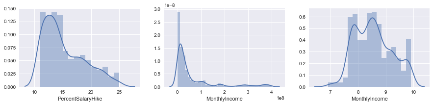

```python
import seaborn as sns
import matplotlib.pyplot as plt
%matplotlib inline
sns.set(color_codes=True)
fig = plt.figure(figsize = (15,10))
fig.clf()
plt.subplot(331)
x = Emp_Attrition["PercentSalaryHike"]
sns.distplot(x)
plt.subplot(332)
x =np.square(Emp_Attrition["MonthlyIncome"])
sns.distplot(x)
plt.subplot(333)
x =np.log(Emp_Attrition["MonthlyIncome"]+1)
sns.distplot(x)
```

### Data Exploration and Visualization of Dataset

I have created the two functions EA_snsbox, EA_bar for creating the boxplots and bar charts on various predictors variables

```python
# Creates boxplots on the data
def EA_snsbox(df,col):
    import matplotlib
    import numpy as np
    import seaborn as sns
    import matplotlib.pyplot as plt
    sns.set_style("dark")
    g=sns.boxplot(x="Attrition",y=col,data= df,palette="Set1")
    sns.plt.title('Box plot of ' + col + '\n for Employee Attrition')
    g.set_xticklabels(labels=df["Attrition"], rotation=90)

# creates the bar charts on the data
def EA_bar(df, cols):
    import seaborn as sns
    import matplotlib.pyplot as plt
    pf=df.groupby([cols,"Attrition"]).size().reset_index(name='counts')
    sns.set_style("dark")
    g=sns.barplot(x=cols, y="counts",hue="Attrition", data=pf)
    sns.plt.title(cols +' vs. \n Employee Attrition')
    sns.plt.ylabel('Count')
    g.set_xticklabels(labels=np.unique(pf[cols]), rotation=90)

# Interaction between various variables
def EA_VP(df,col1,col2):
    import seaborn as sns
    import matplotlib.pyplot as plt
    sns.set_style("dark")
    g = sns.violinplot(x=col1, y=col2, hue="Attrition",
                        data=df, palette="Set2", split=True,scale="count")
    sns.plt.title('Voilinplots: ' + col1 + 'Vs' + col2 + '\n for Employee Attrition')
    g.set_xticklabels(labels=np.unique(df[col1]), rotation=90)
```

#### Employee Attrition versus Age,Gender and Marital Status

Many studies have linked age, gender, and relationship status with job satisfaction. Like for example the senior citizen have the highest level of job satisfaction among the U.S. workers. It is generally believed that job satisfaction increases with age. So does it mean younger employee tends to quite jobs and seek another opportunity more than older folks. Are the woman folks more satisfied with their jobs or its other way around? Is there an empirical relationship between marital status and job satisfaction?

Let’s try the answer the above questions, by visually exploring the data of this fictitious company.

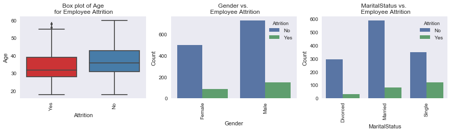

```python
%matplotlib inline
import matplotlib.pyplot as plt
fig = plt.figure(figsize = (15,10))
fig.clf()
plt.subplot(331)
EA_snsbox(Emp_Attrition,"Age")
plt.subplot(332)
EA_bar(Emp_Attrition, "Gender")
plt.subplot(333)
EA_bar(Emp_Attrition, "MaritalStatus")
```

In the above plot (*left*), the median age of people who have quit their jobs is much less than the people not quit their jobs.

#### Work Life Balance

Work-life balance varies from person to person and from generation to generation of the workforce. Employers need to take into consideration the healthy work-life balance needs of each employee. Work-life balance programs can reduce employee turnover and improve recruitment, increasing the productivity. In this section, let’s explore relation between different factors like 'Distance from Home', 'Over-Time ‘, 'Work-Life balance’ and the employee attrition.

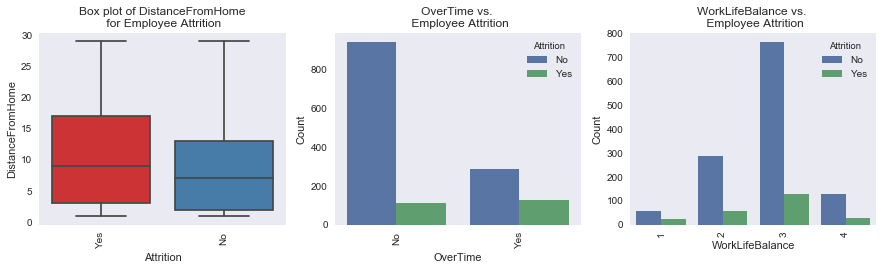

```python
fig = plt.figure(figsize = (15,12))
fig.clf()
plt.subplot(331)
EA_snsbox(Emp_Attrition,"DistanceFromHome")
plt.subplot(332)
EA_bar(Emp_Attrition, "OverTime")
plt.subplot(333)
EA_bar(Emp_Attrition, "WorkLifeBalance")
```

The median distance to travel from home to office for employees who have quit their jobs is high as compare to employees who have not quit their jobs. Approximately about 70% of employees in the company do not have to overtime. About 30% of people who have do overtime have left their jobs.

*Work-Life Balance(: 6% employees feel their work-life balance is 'Bad', 23% feels it is 'Good', 61% of employees feels they have 'Better' work-life balance, 10% employees feel they have the 'Best' work-life balance. From the above plot, we can say the employees of the company are satisfied with their work-life balance in general. Only 6% employees feel their work-life balance is bad and 31% of this category have left the job.

### Job Profile

Most employees quit their first job after gaining skills and experience from the first job for career advancement and position. In this section, let’s explore the relationship between the job level and employee attrition.

**Department Vs Employee Attrition**: Is there any specific department in the company, where the attrition rate is very high.

**Business Travel Vs Employee Attrition**: Some people love to travel for work, some people don't like it. How does the work related travel influence the employee decision to quit?

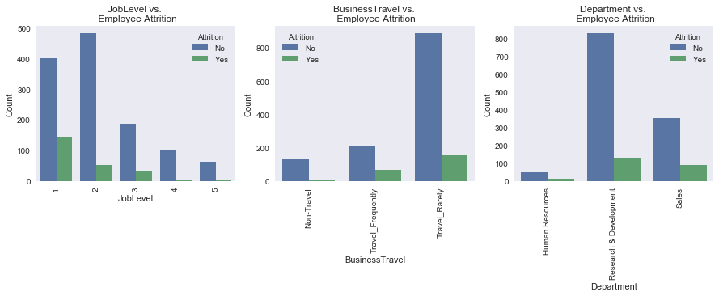

```python
fig = plt.figure(figsize = (15,12))
fig.clf()
plt.subplot(331)
EA_bar(Emp_Attrition, "JobLevel")
plt.subplot(332)
EA_bar(Emp_Attrition, "BusinessTravel")
plt.subplot(333)
EA_bar(Emp_Attrition, "Department")
```

About 60% of the employees who have left the company were working at different 'entry-level’ positions in company,22% were working at 'intermediate' position,14% were experience employees ,4% were in advance or Expert level.

19% of employees have to travel frequently, 81% have 'Non-Travel' or 'Travel_Rarely' profile in the company. About 25% employee who have to travel frequently have left their jobs.

#### Job Satisfaction and Environment Satisfaction

High-performing employees need a challenging environment for professional growth and development or may get bored. It is important to check are there right people for right roles, how is job involvement are people getting recognition. The work environment is other important factor causing people to move or remain a company. The plots below reinforces the above comment about the employee attrition due to Satisfaction and Environment Satisfaction

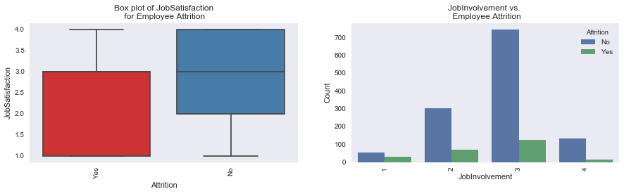

```python
fig = plt.figure(figsize = (15,8))
fig.clf()
plt.subplot(221)
EA_snsbox(Emp_Attrition, "JobSatisfaction")
plt.subplot(222)
EA_bar(Emp_Attrition, "JobInvolvement")
```

The above plots reinforce the believe that higher the job satisfaction level and job involvement levels are the lesser the employee is likely to quite her job

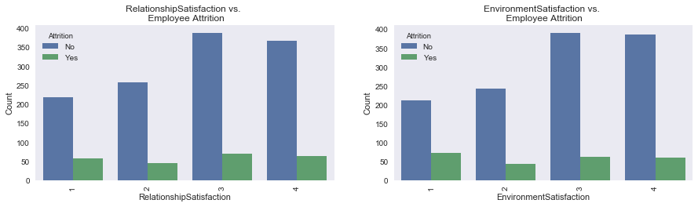

```python
fig = plt.figure(figsize = (15,8))
fig.clf()
plt.subplot(221)
EA_bar(Emp_Attrition, "RelationshipSatisfaction")
plt.subplot(222)
EA_bar(Emp_Attrition, "EnvironmentSatisfaction")
```

The above plot shows how relationship and Environmental satisfaction plays a role in person decision to quite her job. Higher the Relationship satisfaction level and environment satisfaction levels less likely an employee to quit her job.

#### Higher pay

A better offer can trigger the most efficient employee to leave the company. Many companies give additional perks such as flexible schedules, remote work, discount on services and travel to their employees. Rewarding the employees with stock options and salary hikes are some common practices. Let explore how these factors impact the employee attrition outcome

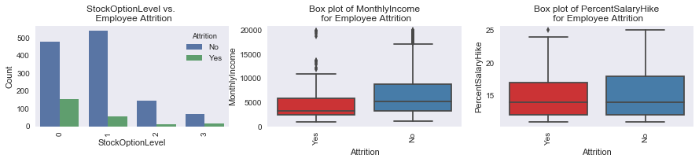

```python
fig = plt.figure(figsize = (15,8))
fig.clf()
plt.subplot(331)
EA_bar(Emp_Attrition, "StockOptionLevel")
plt.subplot(332)
EA_snsbox(Emp_Attrition, "MonthlyIncome")
plt.subplot(333)
EA_snsbox(Emp_Attrition, "PercentSalaryHike")
```

From the above graph it is clear that the median salary of the people who have left, is much lower than employees who have not.

Percentage Salary hike is little more, for people who have not quitted as compare to those who have left.

#### Bored, Poor Managed or not engaged

A bad immediate manager can make any employee miserable. Employees often quit a job due to the relationship they have with their manager. Providing training and development opportunities to employees is crucial to retain them. Proactive approach to build a strong employer-employee relationship may result in less employee attrition. In this section, let visualize the parameters like 'YearsWithCurrManager','YearsSinceLastPromotion','TrainingTimesLastYear', 'TotalWorkingYears' etc. in a pairs plot

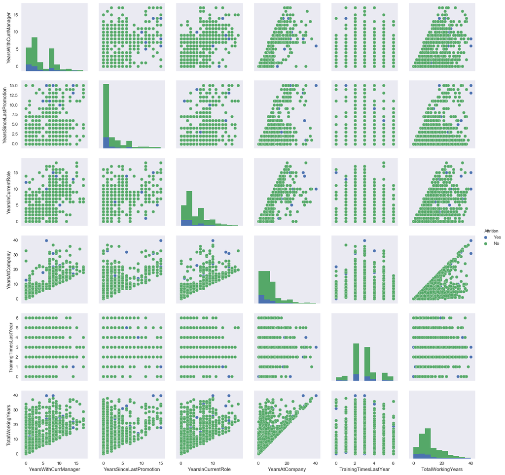

```python
df=Emp_Attrition.loc[:,["Attrition","YearsWithCurrManager","YearsSinceLastPromotion","YearsInCurrentRole",
                     "YearsAtCompany","TrainingTimesLastYear","TotalWorkingYears"]]
sns.pairplot(df, hue="Attrition")
```

So factors like Monthly income, Environmental satisfaction, Job Involvement, when was the employee promoted last time, how many years the employee is serving in the current role, how many years of total work experience are of our interest in predicting a model. As the work environment, around the world is changing dynamically, new skills could be needed for the current position, so it is important that both employer and employees spend good amount of time in training.

### Interaction between various variables

Let explore the relationship between the variables job level, total years of experience, attrition and job level, attrition, monthly income. It can be seen in the plot below that the entry level jobs have less work experience and the monthly income for entry level is very less as compare to intermediate or experience level. The entry level employees are most likely to quit their jobs.

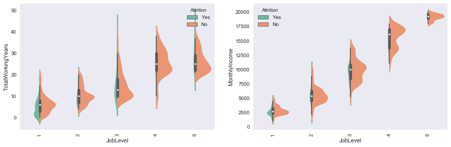

```python
fig = plt.figure(figsize = (15,10))
fig.clf()
plt.subplot(221)
EA_VP(Emp_Attrition,"JobLevel","TotalWorkingYears")
plt.subplot(222)
EA_VP(Emp_Attrition,"JobLevel","MonthlyIncome")
```

Lower the job satisfaction level and working years with the current manager, the employee is likely to quit

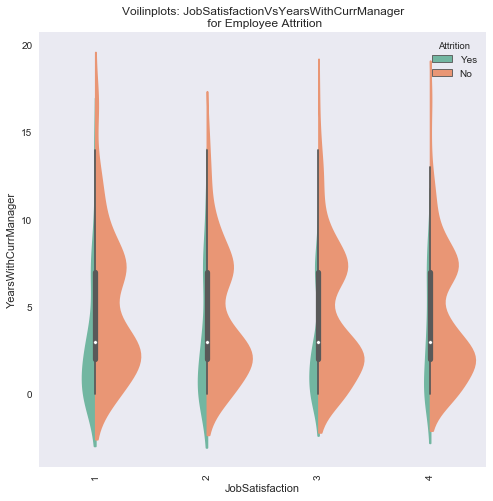

```python
fig = plt.figure(figsize = (8,8))
EA_VP(Emp_Attrition,"JobSatisfaction","YearsWithCurrManager")
```

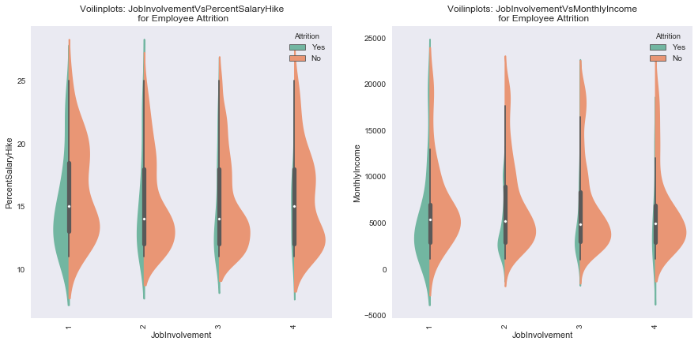

```python
fig = plt.figure(figsize = (15,15))
fig.clf()
plt.subplot(221)
EA_VP(Emp_Attrition,"JobInvolvement","PercentSalaryHike")
plt.subplot(222)
EA_VP(Emp_Attrition,"JobInvolvement","MonthlyIncome")
```

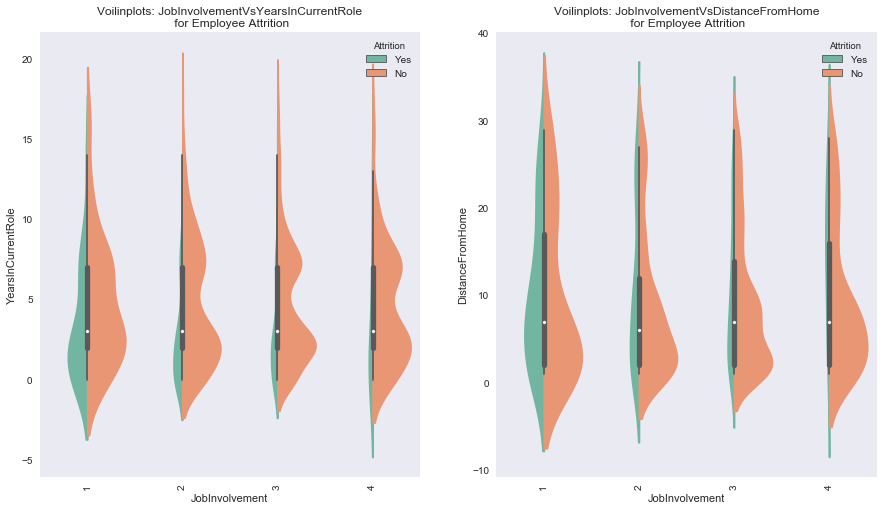

```python
fig = plt.figure(figsize = (15,18))
fig.clf()
plt.subplot(221)
EA_VP(Emp_Attrition,"JobInvolvement","YearsInCurrentRole")
plt.subplot(222)
EA_VP(Emp_Attrition,"JobInvolvement","DistanceFromHome")
```

*Right plot*: With low job involvement but high monthly income a person will not quit, but it will be a disadvantage to the organization

*Left Plot* : With low job involvement even a hike in salary percentag will not able to retain an employee.

It looks like the Job Involvement is one of the most important factors which can lead to employee attrition

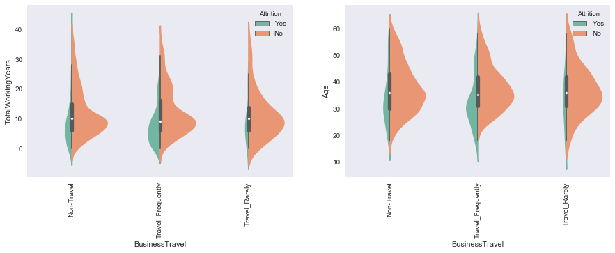

```python
fig = plt.figure(figsize = (15,10))
fig.clf()
plt.subplot(221)
EA_VP(Emp_Attrition,"BusinessTravel","TotalWorkingYears")
plt.subplot(222)
EA_VP(Emp_Attrition,"BusinessTravel","Age")
```

### Pre-Processing of Dataset

It is important to pre-process the data before doing the actually analysis. This steps involves :-

```
1. Handling the missing data
2. Droping the redundant columns.
3. Scaling or Normalization of data (as needed)
```

**1.Droping the redundant columns:**

```python
import pandas as pd
import numpy as np

Emp_Attrition_1= Emp_Attrition.drop(['Over18','StandardHours',
'EmployeeCount','EmployeeNumber','DailyRate','EducationField','HourlyRate',
'JobRole','MonthlyRate','PerformanceRating' ],axis=1)
# Independent Variable
X = Emp_Attrition_1
X= X.drop(X.columns[[1]],axis=1)
# dependent Variable
Y= Emp_Attrition_1.iloc[:, 1]
X.columns
```

```
Index(['Age', 'BusinessTravel', 'Department', 'DistanceFromHome', 'Education',
       'EnvironmentSatisfaction', 'Gender', 'JobInvolvement', 'JobLevel',
       'JobSatisfaction', 'MaritalStatus', 'MonthlyIncome',
       'NumCompaniesWorked', 'OverTime', 'PercentSalaryHike',
       'RelationshipSatisfaction', 'StockOptionLevel', 'TotalWorkingYears',
       'TrainingTimesLastYear', 'WorkLifeBalance', 'YearsAtCompany',
       'YearsInCurrentRole', 'YearsSinceLastPromotion',
       'YearsWithCurrManager'],
      dtype='object')
```

**2.Coverting categorical data into number:**

Many Machine Learning tools accept only numbers as input, this can cause a problem as the above dataset has some categorical predictor variables too. To convert them as number I have used the 'LabelEncoder'. To convert the nominal variables like ‘Marital status’, ‘Gender’,’OverTime’ etc. I used the 'One-Hot-encoder' form sklearn.preprocessing.

```python
from sklearn.preprocessing import LabelEncoder,OneHotEncoder
# Converting categorical values into numerical values
labelencoder_x= LabelEncoder()
for i in [1,2,6,10,13]:
    X.iloc[:, i]=labelencoder_x.fit_transform( X.iloc[:, i])

# creating columns for categorical values
onehotencoder =OneHotEncoder(categorical_features=[1,6,10,13])
X=onehotencoder.fit_transform(X).toarray()
# yes/no into numerical values
Y=labelencoder_x.fit_transform(Y)
```

**3. Spliting Data into train and Test**

To get a honest assessments of the performance of our predictive model, it is essential to split the data into a train and test dataset.

```python
# spliting the data into test and training set
from sklearn.model_selection import  train_test_split
# 20% of test data
X_train,X_test, Y_train, Y_test= train_test_split(X,Y,test_size=0.2,random_state=12345)
```

# CLASSIFICATION

### 1. RANDOM FOREST

Random forest classifier is an ensemble learning method for classification. The number of tree in the forest (n_estimators) =100. The 'Gini impurity' is used to measure the quality of split.

```python
from sklearn.ensemble import  RandomForestClassifier
rf_model= RandomForestClassifier(n_estimators=100,
                                 oob_score=True,
                                 criterion= 'gini',
                                 max_features=7,
                                 random_state=16333336)

rf_model.fit(X_train, Y_train)
print(rf_model.feature_importances_)
```

```
[ 0.00331329  0.02204643  0.00856639  0.00868279  0.01006086  0.00777565
  0.00895881  0.01811777  0.03281144  0.0333426   0.07946485  0.02464921
  0.0622094   0.02351176  0.03412768  0.02985646  0.0229439   0.0406429
  0.09858761  0.04728507  0.04391905  0.02784448  0.03571516  0.0589936
  0.03508337  0.0302737   0.05281346  0.03303456  0.03362409  0.03174366]
```

**Cross Validation with K=10 folds**

```python
import sklearn.model_selection as  model_selection
kfold = model_selection.KFold(n_splits =10,random_state=1452345)

#cross validation
scores = model_selection.cross_val_score(rf_model, X_train, Y_train, cv=kfold, scoring='accuracy')
print("Train accuracy %0.2f (+/- %0.2f)" % (scores.mean()*100, scores.std()*100))

# Predicting the test output
from sklearn.metrics import accuracy_score,roc_curve, auc
preds = model_selection.cross_val_predict(rf_model, X_test, Y_test, cv=kfold)
print("Test accuracy %0.2f" % (100* accuracy_score(Y_test, preds)))
```

```
Train accuracy 85.11 (+/- 2.40)
Test accuracy 86.73
```

**Area under the Curve(AUC)**:

```python
rf_model= RandomForestClassifier(n_estimators=100,
                                 oob_score=True,criterion= 'gini',
                                 max_features=7,random_state=35666666)

rf_model.fit(X_train,Y_train)
fpr_rf, tpr_rf, _ = roc_curve(Y_test, rf_model.predict_proba(X_test)[:,1])
# Calculate the AUC
roc_auc_r = auc(fpr_rf, tpr_rf)
print('ROC AUC: %0.2f' % roc_auc_r)
```

```
ROC AUC: 0.83
```

### 2. Logistic Regression

Before apply the Logistic Regression classifier and support vector Machine classifier, first we need to scale or normalized the data.

Logistic regression also known as **logit regression** is a regression model where the dependent variable is categorical variable. Here 'C' is inverse of regularization strength, smaller values specify stronger regularization. The function for tuning the parameters available in scikit-learn is called gridSearchCV() is used to get bets parameters.

**param_grid**: It is the dictionary or list with parameters names (string) as keys and lists of parameter settings to try as values. The penalty used is "l2"

```python
# scaling data
from sklearn.preprocessing import StandardScaler
sc_X= StandardScaler()
X_train =sc_X.fit_transform(X_train)
X_test =sc_X.transform(X_test)
```

**Tuning of Parameters**

```python
from sklearn.linear_model import LogisticRegression
from sklearn.model_selection import GridSearchCV
param_grid_l={'C':[0.001,0.01,0.1,1,10,100,1000],
              'tol':[0.1,0.01,0.001,0.0001]}
CV_log = GridSearchCV(cv=10,
                      estimator=LogisticRegression(C=1.0,penalty='l2',tol=0.001)
                      , param_grid= param_grid_l)

CV_log.fit(X_train,Y_train)
print(CV_log.best_params_)
```

```
{'C': 0.01, 'tol': 0.1}
```

**Cross Validation with K=10 folds**

```python
from sklearn import model_selection
scores =model_selection.cross_val_score(CV_log, X_train, Y_train, cv=kfold, scoring='accuracy')

print("Train accuracy %0.2f (+/- %0.2f)" % (scores.mean()*100, scores.std()*100))

# Predicting the
from sklearn.metrics import accuracy_score,roc_curve, auc
cv_preds=list()
preds = model_selection.cross_val_predict(CV_log, X_test, Y_test, cv=kfold)

print("Test accuracy %0.2f" % (100* accuracy_score(Y_test, preds)))
```

```
Train accuracy 86.90 (+/- 2.23)
Test accuracy 86.39
```

**Area under the Curve(AUC):**

```python
logR_clf= LogisticRegression(C=1000,penalty='l2',tol=0.1)
logR_clf.fit(X_train,Y_train)
fpr_l, tpr_l, _ = roc_curve(Y_test, logR_clf.predict_proba(X_test)[:,1])
# Calculate the AUC
roc_auc_l = auc(fpr_l, tpr_l)
print('ROC AUC: %0.2f' % roc_auc_l)
```

```
ROC AUC: 0.84
```

### 3. Support Vector Machine Classifer

The class used for SVM classification in scikit-learn is svm.SVC(). The parameter for SVM classifier:

1. C: It is the regularization parameter, C, of the error term.
2. kernel: It specifies the kernel type to be used in the algorithm. It can be ‘linear’, ‘poly’, ‘rbf’, ‘sigmoid’, ‘precomputed’, or a callable. The default value is ‘rbf'.
3. degree: It is the degree of the polynomial kernel function (‘poly’) and is ignored by all other kernels. The default value is 3.
4. gamma: It is the kernel coefficient for ‘rbf’, ‘poly’, and ‘sigmoid’. If gamma is ‘auto’, then 1/n_features will be used instead.

The SVM is tune by changing parameters C, gamma and the kernel function. The function for tuning the parameters is called gridSearchCV(). param_grid: It is the dictionary or list with parameters names (string) as keys and lists of parameter settings to try as values.

**Tunning of parameter**

```python
from sklearn.svm import SVC
from sklearn.model_selection import GridSearchCV
svc=SVC()
param_grid= {
        "kernel":['linear','rbf'],
        "gamma":[0.01,0.02,0.05,0.1],
        "C" : [1,10,100]}
CV_svc = GridSearchCV(estimator=svc, param_grid= param_grid,cv=10)
CV_svc.fit(X_train,Y_train)
print(CV_svc.best_params_)
cv_scores = list()
from sklearn import model_selection
svc2= SVC()
svc=SVC(C =10 ,kernel ="rbf",gamma=0.1)
kfold = model_selection.KFold(n_splits =10,random_state=16792345)
print("done")
```

```
{'C': 10, 'gamma': 0.01, 'kernel': 'rbf'}
done
```

```python
from sklearn import model_selection
scores =model_selection.cross_val_score(svc, X_train, Y_train, cv=kfold, scoring='accuracy')

cv_scores.append(scores.mean()*100)
print("Train accuracy %0.2f (+/- %0.2f)" % (scores.mean()*100, scores.std()*100))

# Predicting the
from sklearn.metrics import accuracy_score,roc_curve, auc
cv_preds=list()
preds = model_selection.cross_val_predict(svc, X_test, Y_test, cv=kfold)
cv_preds.append(accuracy_score(Y_test, preds)*100)
print("Test accuracy %0.2f" % (100* accuracy_score(Y_test, preds)))
```

```
Train accuracy 84.77 (+/- 2.72)
Test accuracy 86.73
```

**Area under the Curve(AUC):**

```python
import matplotlib.pyplot as plt
svc=SVC(C =10 ,kernel ="rbf",gamma=0.01,probability= True)
svc.fit(X_train,Y_train)
from sklearn.metrics import roc_curve, auc
fpr, tpr, _ = roc_curve(Y_test, svc.predict_proba(X_test)[:,1])
# Calculate the AUC
roc_auc_s = auc(fpr, tpr)
print('ROC AUC: %0.2f' % roc_auc_s)
```

```
ROC AUC: 0.79
```

### Comparing Support Vector Machine, Logistic Regression and Random Forest Classifier

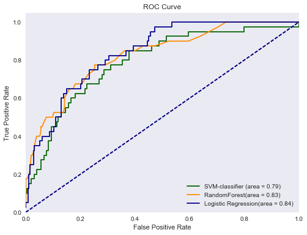

```python
import matplotlib.pyplot as plt
plt.figure(figsize=(8, 6))
plt.plot(fpr, tpr, color='darkgreen',label='SVM-classifier (area = %0.2f)' % roc_auc_s)
plt.plot(fpr_rf, tpr_rf, color='darkorange',label='RandomForest(area = %0.2f)' % roc_auc_r)
plt.plot(fpr_l, tpr_l, color='darkblue',label='Logistic Regression(area = %0.2f)' % roc_auc_l)
plt.plot([0, 1], [0, 1], color='navy', lw=2, linestyle='--')
plt.xlim([0.0, 1.0])
plt.ylim([0.0, 1.05])
plt.xlabel('False Positive Rate')
plt.ylabel('True Positive Rate')
plt.title('ROC Curve')
plt.legend(loc="lower right")
plt.show()
```

```python
All the three classifier gives a Training accuracy of 84% to 87 % and Test accuracy of approximately
86%. When we compare the Area under the ROC curve for the three classifier, the Logistic Regression classifier seems
to perform slightly better than the other two classifiers.
```

## AZURE MACHINE LEARNING

Now lets try to the modelling and predictions using the Azure Machine Learning tool. In the Azure Machine learning studio,I tried using Two-class Logistic Regression, Two-class Boosted Decision Tree, Two-class Support Vector Machine and Two-class Neural Network module to classify the employees who quit and who will not quit.

#### 4. Model Deployement as Web Service

The model is deployed as a web service, it can be used anyone to make predictions, whether the employee will quit or not based on the prediction variables discussed above.

Here's the api key and url

1. The API Key: **uWa1MuYEu1aPo7p3uqt4bdZ6EbCGx1NVGEKOOziEGy2ThzQAPJQeknZ80QU4a5VgREMV3sJyHeCLvuZJ4dfw2A==**
2. The url : [URL](https://studio.azureml.net/apihelp/workspaces/2a28c6f2bec04ae4b94d96d6016e379a/webservices/94d2c490a9234fafb090eab10465c747/endpoints/a1870786be7544a8bd06415c69669b15/score)

#### 5. Making prediction using Excel

- Open https://office.live.com/start/Excel.aspx . Create a blank notebook. On the insert tab, click Office Add-ins. Add the Azure Machine learning add-in.
- After the add-in is installed, in the Azure Machine learning pane on right of the excel workbook, click Add Web Services and add the API key into API key box.
- After the web service has been added, in the Azure ML pane, click 1.View schema and note the inputs expected by the web service and the output returned by the web service.
- In excel worksheet select cell A1. Then in Azure ML pane, collapse the 1.View Schema section and in the 2. predict section, click use sample data.
- Modify the sample data in row and put the predictor variables for which you want to test the model

## Conclusion

It is also observed that the company has failed to retain its entry level people. To avoid the attrition of entry-level employees, take steps like training, attractive paychecks. While employee training and development can seem time consuming and inefficient, employee training for entry-level hires can ensure greater retention within the company and more competent coworkers down the line. In the data exploration section, we observe that the entry level employees are not paid very well. HR should take notice of it, the performance of entry–level employees should be evaluated on regular basis and high performing entry level employees should be rewarded by increasing their salaries or by giving promotion in the job role or both.

Job-satisfaction and Job Involvement are next big factors for retaining an employee. Keeping employees involve and satisfied takes more than just good pay and benefits. Management should ensure the employees are involved and satisfied with their job roles. The more involve is the employee less likely he/she quitting the job. Other important factors which the management should look into are:

• Business-travel: About 25% employee who have to travel frequently have left their jobs.

• Number of years spend with current manager and current role: It is observed that more the numbers of years with the current manager, the less an employee is likely to quite.

• Martial-Status: more single people are likely to quit their jobs than married or divorced people